```python
# python 3.6
import pandas as pd
import matplotlib.pyplot as plt
import seaborn as sns
import numpy as np
import itertools
import timeit
import datetime as dt

%matplotlib inline
```

# 1. Data Exploration

## 1.1 Data Loading

Let's first load the data and see what kind of information we have now.

```python
# Load data
trip_df = pd.read_csv("bikes_data/data/trip_data.csv")
weather_df = pd.read_csv("bikes_data/data/weather_data.csv")
station_df = pd.read_csv("bikes_data/data/station_data.csv")
```

```python
trip_df.head()
```

|  | Trip ID | Start Date | Start Station | End Date | End Station | Subscriber Type |
| --- | --- | --- | --- | --- | --- | --- |
| 0 | 913460 | 31/08/2015 23:26 | 50 | 31/08/2015 23:39 | 70 | Subscriber |
| 1 | 913459 | 31/08/2015 23:11 | 31 | 31/08/2015 23:28 | 27 | Subscriber |
| 2 | 913455 | 31/08/2015 23:13 | 47 | 31/08/2015 23:18 | 64 | Subscriber |
| 3 | 913454 | 31/08/2015 23:10 | 10 | 31/08/2015 23:17 | 8 | Subscriber |
| 4 | 913453 | 31/08/2015 23:09 | 51 | 31/08/2015 23:22 | 60 | Customer |

```python
weather_df.head()
```

|  | Date | Max TemperatureF | Mean TemperatureF | Min TemperatureF | Max Dew PointF | MeanDew PointF | Min DewpointF | Max Humidity | Mean Humidity | Min Humidity | ... | Mean VisibilityMiles | Min VisibilityMiles | Max Wind SpeedMPH | Mean Wind SpeedMPH | Max Gust SpeedMPH | PrecipitationIn | CloudCover | Events | WindDirDegrees | Zip |
| --- | --- | --- | --- | --- | --- | --- | --- | --- | --- | --- | --- | --- | --- | --- | --- | --- | --- | --- | --- | --- | --- |
| 0 | 01/09/2014 | 83.0 | 70.0 | 57.0 | 58.0 | 56.0 | 52.0 | 86.0 | 64.0 | 42.0 | ... | 10.0 | 8.0 | 16.0 | 7.0 | 20.0 | 0.0 | 0.0 | NaN | 290.0 | 94107 |
| 1 | 02/09/2014 | 72.0 | 66.0 | 60.0 | 58.0 | 57.0 | 55.0 | 84.0 | 73.0 | 61.0 | ... | 10.0 | 7.0 | 21.0 | 8.0 | NaN | 0.0 | 5.0 | NaN | 290.0 | 94107 |
| 2 | 03/09/2014 | 76.0 | 69.0 | 61.0 | 57.0 | 56.0 | 55.0 | 84.0 | 69.0 | 53.0 | ... | 10.0 | 10.0 | 21.0 | 8.0 | 24.0 | 0.0 | 4.0 | NaN | 276.0 | 94107 |
| 3 | 04/09/2014 | 74.0 | 68.0 | 61.0 | 57.0 | 57.0 | 56.0 | 84.0 | 71.0 | 57.0 | ... | 10.0 | 8.0 | 22.0 | 8.0 | 25.0 | 0.0 | 5.0 | NaN | 301.0 | 94107 |
| 4 | 05/09/2014 | 72.0 | 66.0 | 60.0 | 57.0 | 56.0 | 54.0 | 84.0 | 71.0 | 57.0 | ... | 9.0 | 7.0 | 18.0 | 8.0 | 32.0 | 0.0 | 4.0 | NaN | 309.0 | 94107 |

5 rows × 24 columns

```python
station_df.head()
```

|  | Id | Name | Lat | Long | Dock Count | City |
| --- | --- | --- | --- | --- | --- | --- |
| 0 | 2 | San Jose Diridon Caltrain Station | 37.329732 | -121.901782 | 27 | San Jose |
| 1 | 3 | San Jose Civic Center | 37.330698 | -121.888979 | 15 | San Jose |
| 2 | 4 | Santa Clara at Almaden | 37.333988 | -121.894902 | 11 | San Jose |
| 3 | 5 | Adobe on Almaden | 37.331415 | -121.893200 | 19 | San Jose |
| 4 | 6 | San Pedro Square | 37.336721 | -121.894074 | 15 | San Jose |

## 1.2 Data Summary

```python
print("trip:", trip_df.shape)
print("weather: ", weather_df.shape)
print("station: ", station_df.shape)
```

```
trip: (354152, 6)
weather:  (1825, 24)
station:  (76, 6)
```

```python
# Explore trip data
trip_df.isnull().sum()
```

```
Trip ID            0
Start Date         0
Start Station      0
End Date           0
End Station        0
Subscriber Type    0
dtype: int64
```

```python
trip_df.head(1)
```

|  | Trip ID | Start Date | Start Station | End Date | End Station | Subscriber Type |
| --- | --- | --- | --- | --- | --- | --- |
| 0 | 913460 | 31/08/2015 23:26 | 50 | 31/08/2015 23:39 | 70 | Subscriber |

```python
trip_df.tail(1)
```

|  | Trip ID | Start Date | Start Station | End Date | End Station | Subscriber Type |
| --- | --- | --- | --- | --- | --- | --- |
| 354151 | 432947 | 01/09/2014 00:05 | 66 | 01/09/2014 00:15 | 57 | Customer |

```python
# Explore station data
station_df.isnull().sum()
```

```
Id            0
Name          0
Lat           0
Long          0
Dock Count    0
City          0
dtype: int64
```

```python
station_df.City.unique()
```

```
array(['San Jose', 'Redwood City', 'Mountain View', 'Palo Alto',
       'San Francisco'], dtype=object)
```

```python
# Explore weather data
weather_df['Zip'].value_counts()
```

```
94107    365
94063    365
94041    365
95113    365
94301    365
Name: Zip, dtype: int64
```

```python
weather_df.isnull().sum()
```

```
Date                            0
Max TemperatureF                4
Mean TemperatureF               4
Min TemperatureF                4
Max Dew PointF                 50
MeanDew PointF                 50
Min DewpointF                  50
Max Humidity                   50
Mean Humidity                  50
Min Humidity                   50
Max Sea Level PressureIn        1
Mean Sea Level PressureIn       1
Min Sea Level PressureIn        1
Max VisibilityMiles             5
Mean VisibilityMiles            5
Min VisibilityMiles             5
Max Wind SpeedMPH               1
Mean Wind SpeedMPH              1
Max Gust SpeedMPH             541
PrecipitationIn                 1
CloudCover                      1
Events                       1538
WindDirDegrees                  1
Zip                             0
dtype: int64
```

```python
weather_df.Events.unique()
```

```
array([nan, 'Rain', 'Fog', 'Fog-Rain', 'Rain-Thunderstorm'], dtype=object)
```

#### Dataset Summary:

- **Trip data:** in the dataset, there are total 354152 trips, range from 2014-09-01 to 2015-08-31. That is, one year of trip data. There are two types of customer: Subscriber (annual or 30-day member) and Customer (24-hour or 30-day member).
- **Weather data:** There are 1825 weather information for same date range of trip data, that is 365 days of weather record for each City. Briefly, weather information have records of temperature, humidity, sea level pressure, visibility, wind speed, precipitation, cloud cover, wind direction, and special events. Special events are 4 different evens labeled as Rain, Fog, Fog-Rain and Rain-Thunderstorm. But there are lots of data without special event label, which might be a normal day instead.
- **Station data:** There are total 76 stations. As described in the assignment information, 5 of them are moved to a new stations, that is 23, 25, 49, 69, 72 to 85, 86, 87, 88, 89, respectively. And station 89 further moved to station 90. So there are total 70 live stations.

#### Potential Issues:

- **Missing values:** there is no missing value in trip and station data, but weather data have some missing values.

## 1.3 Data Preprocessing

I'll do following steps to preprocess data first:

- Add zipcode to station_df
- Update station number (move old stations to new stations)
- Standardize 'Date' in both trip_df and weather_df
- Impute missing value in weather_df

```python
# Add zipcode to station_df
def get_zip(city_name):
    if city_name == 'San Francisco':
        return 94107
    elif city_name == 'Redwood City':
        return 94063
    elif city_name == 'Mountain View':
        return 94041
    elif city_name == 'San Jose':
        return 95113
    elif city_name == 'Palo Alto':
        return 94301

station_df['Zip'] = station_df['City'].apply(lambda x: get_zip(x))
station_df.head()
```

|  | Id | Name | Lat | Long | Dock Count | City | Zip |
| --- | --- | --- | --- | --- | --- | --- | --- |
| 0 | 2 | San Jose Diridon Caltrain Station | 37.329732 | -121.901782 | 27 | San Jose | 95113 |
| 1 | 3 | San Jose Civic Center | 37.330698 | -121.888979 | 15 | San Jose | 95113 |
| 2 | 4 | Santa Clara at Almaden | 37.333988 | -121.894902 | 11 | San Jose | 95113 |
| 3 | 5 | Adobe on Almaden | 37.331415 | -121.893200 | 19 | San Jose | 95113 |
| 4 | 6 | San Pedro Square | 37.336721 | -121.894074 | 15 | San Jose | 95113 |

```python
# For simplicity, in trip_df, change station number to their moved (new) station number
# So totally we have 70 stations
old_station_ids = [23, 25, 49, 69, 72, 89]
new_station_ids = [85, 86, 87, 88, 89, 90]

for old_id, new_id in zip(old_station_ids, new_station_ids):
    trip_df.loc[trip_df['Start Station'] == old_id, ['Start Station']] = new_id
    trip_df.loc[trip_df['End Station'] == old_id, ['End Station']] = new_id
```

```python
print("# of Start Stations: ", len(trip_df['Start Station'].unique()))
print("# of End Stations: ", len(trip_df['End Station'].unique()))
```

```
# of Start Stations:  70
# of End Stations:  70
```

```python
# Decompose Start and End data to Date, Month and Hour
trip_df['Date_Start'] = pd.to_datetime(trip_df['Start Date'], format= "%d/%m/%Y %H:%M" ).dt.date
trip_df['Date_End'] = pd.to_datetime(trip_df['End Date'], format= "%d/%m/%Y %H:%M" ).dt.date

trip_df['Month_Start'] = pd.to_datetime(trip_df['Start Date'], format= "%d/%m/%Y %H:%M" ).dt.month
trip_df['Month_End'] = pd.to_datetime(trip_df['End Date'], format= "%d/%m/%Y %H:%M" ).dt.month

trip_df['Hour_Start'] = pd.to_datetime(trip_df['Start Date'], format= "%d/%m/%Y %H:%M" ).dt.hour
trip_df['Hour_End'] = pd.to_datetime(trip_df['End Date'], format= "%d/%m/%Y %H:%M" ).dt.hour
```

```python
trip_df.head()
```

|  | Trip ID | Start Date | Start Station | End Date | End Station | Subscriber Type | Date_Start | Date_End | Month_Start | Month_End | Hour_Start | Hour_End |
| --- | --- | --- | --- | --- | --- | --- | --- | --- | --- | --- | --- | --- |
| 0 | 913460 | 31/08/2015 23:26 | 50 | 31/08/2015 23:39 | 70 | Subscriber | 2015-08-31 | 2015-08-31 | 8 | 8 | 23 | 23 |
| 1 | 913459 | 31/08/2015 23:11 | 31 | 31/08/2015 23:28 | 27 | Subscriber | 2015-08-31 | 2015-08-31 | 8 | 8 | 23 | 23 |
| 2 | 913455 | 31/08/2015 23:13 | 47 | 31/08/2015 23:18 | 64 | Subscriber | 2015-08-31 | 2015-08-31 | 8 | 8 | 23 | 23 |
| 3 | 913454 | 31/08/2015 23:10 | 10 | 31/08/2015 23:17 | 8 | Subscriber | 2015-08-31 | 2015-08-31 | 8 | 8 | 23 | 23 |
| 4 | 913453 | 31/08/2015 23:09 | 51 | 31/08/2015 23:22 | 60 | Customer | 2015-08-31 | 2015-08-31 | 8 | 8 | 23 | 23 |

```python
# Standarlize weather_df's Date
weather_df['Date'] = pd.to_datetime(weather_df['Date'], format= "%d/%m/%Y" ).dt.date
```

### Impute missing value in weather data

The weather data contained a lot of missing values. I'll use the following strategies to impute these missing values.

- 'Events' with NaN values will be considered as a 'Normal' day.
- Other missing weather values will be imputed with the last known value in previous days. (forward-filling)

```python
# Fill missing value
weather_df.loc[weather_df.Events.isnull(), 'Events'] = "Normal"
weather_df.fillna(method='ffill', inplace=True)
```

```python
weather_df.isnull().sum()
```

```
Date                         0
Max TemperatureF             0
Mean TemperatureF            0
Min TemperatureF             0
Max Dew PointF               0
MeanDew PointF               0
Min DewpointF                0
Max Humidity                 0
Mean Humidity                0
Min Humidity                 0
Max Sea Level PressureIn     0
Mean Sea Level PressureIn    0
Min Sea Level PressureIn     0
Max VisibilityMiles          0
Mean VisibilityMiles         0
Min VisibilityMiles          0
Max Wind SpeedMPH            0
Mean Wind SpeedMPH           0
Max Gust SpeedMPH            0
PrecipitationIn              0
CloudCover                   0
Events                       0
WindDirDegrees               0
Zip                          0
dtype: int64
```

## 1.4 Data Exploration

Now let's explore the data

### Outcoming and incoming trips by station

Stations with different location may have different number of outcoming/incoming trips, let's first look at this.

```
[Text(0.5,1,'Outcoming trips')]
```

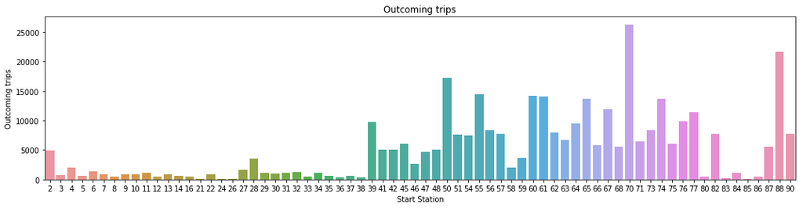

```python
plt.figure(figsize=(18,4))
g = sns.countplot(x = 'Start Station',
              data = trip_df)

g.set(xlabel='Start Station')
g.set(ylabel='Outcoming trips')
g.set(title='Outcoming trips')
```

```
[Text(0.5,1,'Incoming trips')]
```

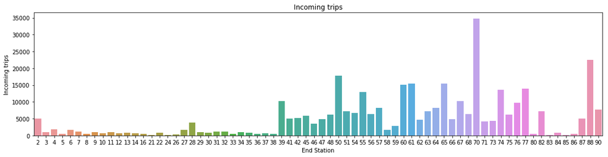

```python
plt.figure(figsize=(18,4))
g = sns.countplot(x = 'End Station',
              data = trip_df)

g.set(xlabel='End Station')
g.set(ylabel='Incoming trips')
g.set(title='Incoming trips')
```

**Observation:** outcoming and incoming trips have very similar pattern, but various a lot in different stations. Station **No.70** is the most busiest one, which has the most outcoming and incoming trips.

### Explore Station 70

Since station 70 has more data, I want to take a deep exploration of this station to see any factors will affect the **net rate** (trip ends - trip started) of this station.

```python
def create_station_df(station_id):
    """
    Create a DataFrame for the station trip data given a station number.
    The station-trip data contains hourly trip info, station info and weather info for this particular station.

    type station_id: int
    rtype: pandas DataFrame
    """
    trip_station_df = trip_df[trip_df['Start Station'] == station_id]
    grouped_start = trip_station_df.groupby(["Date_Start", "Hour_Start"])["Trip ID"].count().reset_index(name="Out_Count")
    grouped_end = trip_station_df.groupby(["Date_End", "Hour_End"])["Trip ID"].count().reset_index(name="In_Count")

    # create new df
    start_date = dt.datetime(2014, 9, 1)
    end_date = dt.datetime(2015, 8, 31)
    index = pd.date_range(start_date, end_date, freq='H') # Hourly index
    df = pd.DataFrame(index=index)
    df['Station'] = station_id
    df['Date'] = df.index.date
    df['Day_Of_Month'] = df.index.day
    df['Hour'] = df.index.hour
    df['Month'] = df.index.month
    df['Weekday'] = df.index.weekday + 1

    # get out_count and in_count number, then calculate net rate
    df = pd.merge(df, grouped_start, left_on=['Date','Hour'], right_on=['Date_Start','Hour_Start'], how='left')
    df = pd.merge(df, grouped_end, left_on=['Date','Hour'], right_on=['Date_End','Hour_End'], how='left')

    df = df.drop(columns=['Date_Start', 'Hour_Start', 'Date_End', 'Hour_End'])
    df = df.fillna(0)
    df[['Out_Count','In_Count']] = df[['Out_Count','In_Count']].astype(int)
    df['Net_Rate'] = df['In_Count'] - df['Out_Count']

    # Get zipcode for the station
    zipcode = station_df[station_df['Id'] == station_id].iloc[0]['Zip']

    # Merge weather data
    df = pd.merge(df, weather_df[weather_df['Zip'] == zipcode], left_on=['Date'], right_on=['Date'], how='left')

    # Fill Normal Events
    #df.loc[df.Events.isnull(), 'Events'] = "Normal"

    # Return df for the station
    return df
```

```python
df_70 = create_station_df(70)
df_70.head()
```

|  | Station | Date | Day_Of_Month | Hour | Month | Weekday | Out_Count | In_Count | Net_Rate | Max TemperatureF | ... | Mean VisibilityMiles | Min VisibilityMiles | Max Wind SpeedMPH | Mean Wind SpeedMPH | Max Gust SpeedMPH | PrecipitationIn | CloudCover | Events | WindDirDegrees | Zip |
| --- | --- | --- | --- | --- | --- | --- | --- | --- | --- | --- | --- | --- | --- | --- | --- | --- | --- | --- | --- | --- | --- |
| 0 | 70 | 2014-09-01 | 1 | 0 | 9 | 1 | 0 | 0 | 0 | 83.0 | ... | 10.0 | 8.0 | 16.0 | 7.0 | 20.0 | 0.0 | 0.0 | Normal | 290.0 | 94107 |
| 1 | 70 | 2014-09-01 | 1 | 1 | 9 | 1 | 0 | 0 | 0 | 83.0 | ... | 10.0 | 8.0 | 16.0 | 7.0 | 20.0 | 0.0 | 0.0 | Normal | 290.0 | 94107 |
| 2 | 70 | 2014-09-01 | 1 | 2 | 9 | 1 | 0 | 0 | 0 | 83.0 | ... | 10.0 | 8.0 | 16.0 | 7.0 | 20.0 | 0.0 | 0.0 | Normal | 290.0 | 94107 |
| 3 | 70 | 2014-09-01 | 1 | 3 | 9 | 1 | 0 | 0 | 0 | 83.0 | ... | 10.0 | 8.0 | 16.0 | 7.0 | 20.0 | 0.0 | 0.0 | Normal | 290.0 | 94107 |
| 4 | 70 | 2014-09-01 | 1 | 4 | 9 | 1 | 0 | 0 | 0 | 83.0 | ... | 10.0 | 8.0 | 16.0 | 7.0 | 20.0 | 0.0 | 0.0 | Normal | 290.0 | 94107 |

5 rows × 32 columns

### Net Rate by Hour (Station 70)

```
[Text(0.5,1,'Net_Rate by Hour (Station 70)')]
```

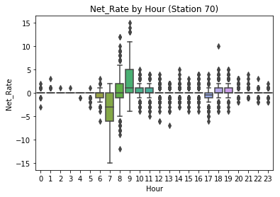

```python
g = sns.boxplot(x='Hour', y = 'Net_Rate', data = df_70)
g.set(title='Net_Rate by Hour (Station 70)')
```

```
[Text(0.5,1,'Net_Rate by Hour (Station 88)')]
```

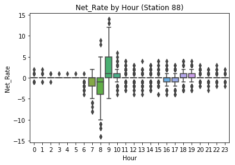

```python
df_88 = create_station_df(88)

g = sns.boxplot(x='Hour', y = 'Net_Rate', data = df_88)
g.set(title='Net_Rate by Hour (Station 88)')
```

### Net Rate by Hour in Different Weekdays (Station 70)

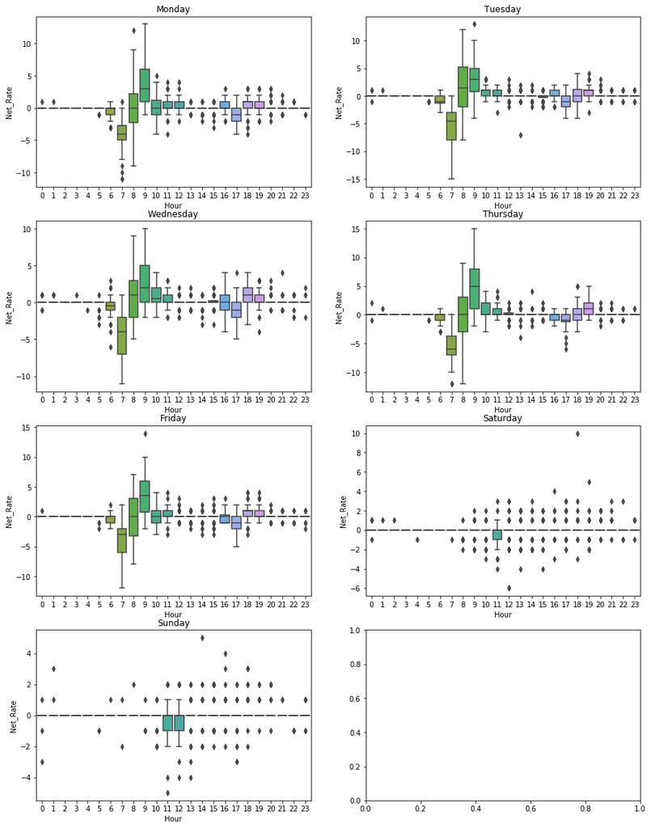

```python
weekday = [1,2,3,4,5,6,7]
title = ['Monday', 'Tuesday', 'Wednesday', 'Thursday', 'Friday', 'Saturday', 'Sunday']
nrows = 4
ncols = 2
fig, ax = plt.subplots(nrows,ncols, figsize=(15,20))

i = 0
for row in range(nrows):
    for col in range(ncols):
        sns.boxplot(x='Hour', y = 'Net_Rate', data = df_70[df_70['Weekday'] == weekday[i]], ax=ax[row][col])
        ax[row][col].set_title(title[i])
        i += 1
        if i == len(weekday):
            break
```

```
Text(0.5,1,'Weekday')
```

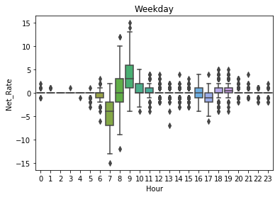

```python
df_ = df_70[df_70['Weekday'].isin([1,2,3,4,5])]
g = sns.boxplot(x='Hour', y = 'Net_Rate', data = df_)
g.set_title('Weekday')
```

```
Text(0.5,1,'Weekend')
```

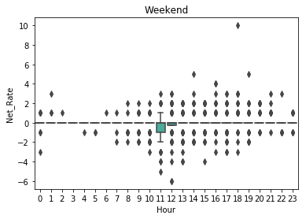

```python
df_ = df_70[df_70['Weekday'].isin([6,7])]
g = sns.boxplot(x='Hour', y = 'Net_Rate', data = df_)
g.set_title('Weekend')
```

### Net Rate by Hour in Different Weather Events (Station 70)

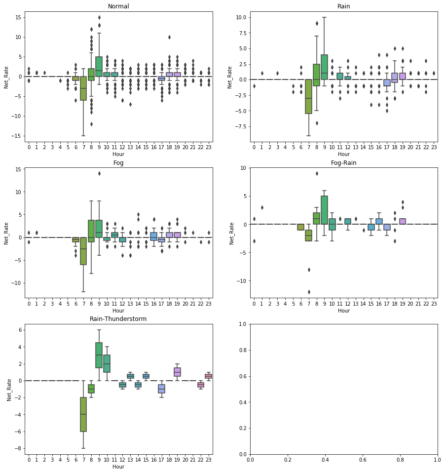

```python
events = weather_df['Events'].unique()

nrows = 3
ncols = 2
fig, ax = plt.subplots(nrows,ncols, figsize=(15, nrows * 5.5))

i = 0
for row in range(nrows):
    for col in range(ncols):
        sns.boxplot(x='Hour', y = 'Net_Rate', data = df_70[df_70['Events'] == events[i]], ax=ax[row][col])
        ax[row][col].set_title(events[i])
        i += 1
        if i == len(events):
            break
```

### Net Rate by Hour in Different Month (Station 70)

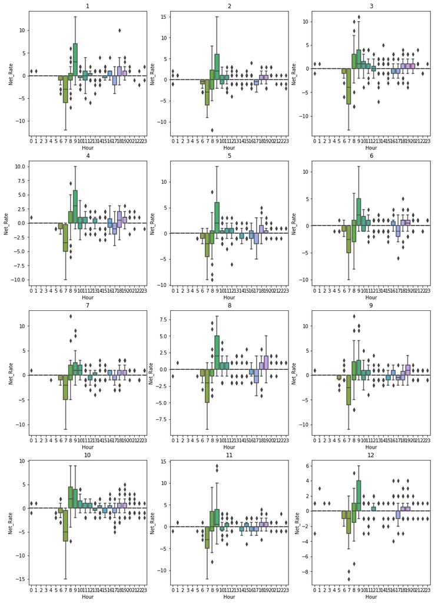

```python
months = range(1,13)

nrows = 4
ncols = 3
fig, ax = plt.subplots(nrows,ncols, figsize=(15, nrows * 5.5))

i = 0
for row in range(nrows):
    for col in range(ncols):
        sns.boxplot(x='Hour', y = 'Net_Rate', data = df_70[df_70['Month'] == months[i]], ax=ax[row][col])
        ax[row][col].set_title(months[i])
        i += 1
        if i == len(months):
            break
```

### Net Rate by Hour in Different Season (Station 70)

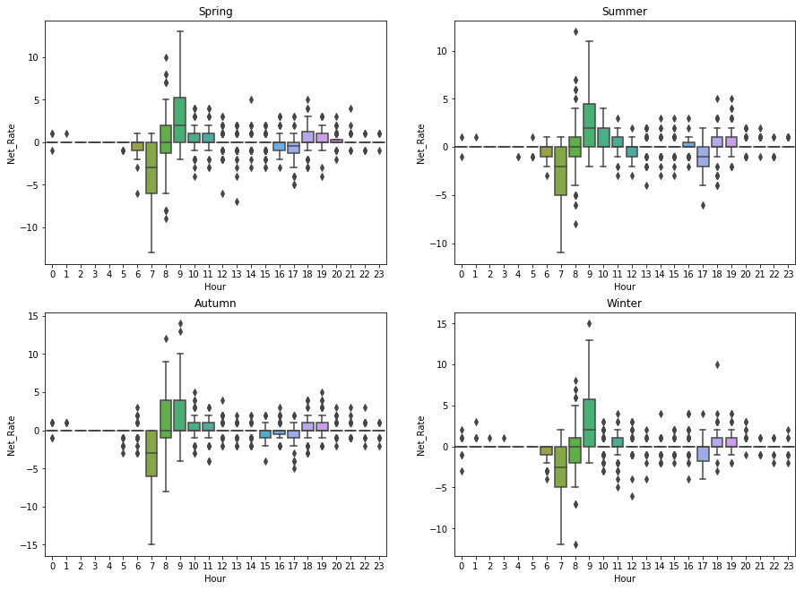

```python
seasons = [[3,4,5], [6,7,8], [9,10,11],[1,2,12]]
season_names = ['Spring', 'Summer', 'Autumn', 'Winter']

nrows = 2
ncols = 2
fig, ax = plt.subplots(nrows,ncols, figsize=(15, nrows * 5.5))

i = 0
for row in range(nrows):
    for col in range(ncols):
        sns.boxplot(x='Hour', y = 'Net_Rate', data = df_70[df_70['Month'].isin(seasons[i])], ax=ax[row][col])
        ax[row][col].set_title(season_names[i])
        i += 1
        if i == len(seasons):
            break
```

### Net Rate by Hour in different stations

Stations with most start trips in each zipcode are:

- 94107: 70
- 95113: 2
- 94041: 28
- 94063: 22
- 94301: 34

```python
df_2 = create_station_df(2)
df_28 = create_station_df(28)
df_22 = create_station_df(22)
df_34 = create_station_df(34)
```

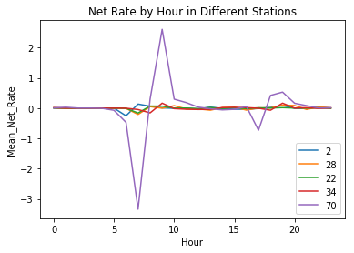

```python
df_2.groupby(['Hour'])['Net_Rate'].mean().plot(label='2')
df_28.groupby(['Hour'])['Net_Rate'].mean().plot(label='28')
df_22.groupby(['Hour'])['Net_Rate'].mean().plot(label='22')
df_34.groupby(['Hour'])['Net_Rate'].mean().plot(label='34')
df_70.groupby(['Hour'])['Net_Rate'].mean().plot(label='70')
plt.ylabel('Mean_Net_Rate')
plt.title('Net Rate by Hour in Different Stations')
plt.legend(loc='lower right')
```

Top 4 stations are:

- 70: 26304 trips
- 88: 21758 trips
- 50: 17255 trips
- 55: 14436 trips

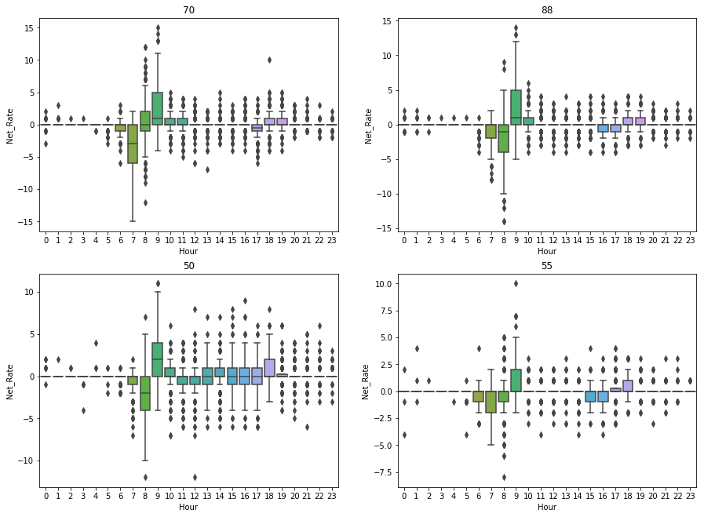

```python
df_88 = create_station_df(88)
df_50 = create_station_df(50)
df_55 = create_station_df(55)

df_list = [df_70, df_88, df_50, df_55]
df_names = [70,88,50,55]

nrows = 2
ncols = 2
fig, ax = plt.subplots(nrows,ncols, figsize=(15, nrows * 5.5))

i = 0
for row in range(nrows):
    for col in range(ncols):
        sns.boxplot(x='Hour', y = 'Net_Rate', data = df_list[i], ax=ax[row][col])
        ax[row][col].set_title(df_names[i])
        i += 1
        if i == len(df_list):
            break
```

# 2. Modeling: Approach and Evaluation

Now we explored the data and find several important factors for the net rate of a station in a given hour. We move to the modeling part.

## 2.1 Prepare Data

First, I'll combine all individual station data into a whole dataframe.

```python
# Create df with all station - trip - weather data
station_list = trip_df['Start Station'].unique()

df = pd.DataFrame()
for station_id in station_list:
    df_ = create_station_df(station_id)
    df = df.append(df_, ignore_index=True)

print(df.shape)
#df.head()
```

```
(611590, 32)
```

```python
# Since we've already impute the missing data, this is no missing data
#df.isnull().sum()
```

### Feature Engineering: more features

From the analysis above, we have seen that hourly net rate bike usage is considerably different on weekdays as compared to weekends. So I'll add a binary feature ('Is_Weekend') for whether any given day is a weekend. Similarly, I also add another binary feature ('Is_Holiday') for whether any given day is a holiday in US.

```python
# Add Is_Weekend feature
df['Is_Weekend'] = df['Weekday'].isin([6,7])

# Add Is_Holiday feature
from pandas.tseries.holiday import USFederalHolidayCalendar as calendar
cal = calendar()
holidays = cal.holidays(start=dt.datetime(2014, 9, 1), end=dt.datetime(2015, 8, 31))
df['Is_Holiday'] = df['Date'].isin(holidays)
```

The Dock Count for each station describes the intensity of usage of the station, this is unique for each station and probably contribute to the pattern of net rate. so I'll extract dock count data from the station_df and merge it into the final data frame.

```python
# Add Dock Count to the station
df = pd.merge(df, station_df[['Id','Dock Count']], left_on=['Station'], right_on=['Id'], how='left')
df = df.drop(columns=['Id'])
```

### Feature Engineering: One-Hot Encoding

Weather 'Events' is a categorical object. Here **one-hot encoding** is used to convert the categorical data.

```python
#df.dtypes
```

```python
x_names = [x for x in df.columns if x not in ['Date']]

df_dummies = pd.get_dummies(df[x_names])
df_dummies.columns
```

```
Index(['Station', 'Day_Of_Month', 'Hour', 'Month', 'Weekday', 'Out_Count',
       'In_Count', 'Net_Rate', 'Max TemperatureF', 'Mean TemperatureF',
       'Min TemperatureF', 'Max Dew PointF', 'MeanDew PointF', 'Min DewpointF',
       'Max Humidity', 'Mean Humidity', 'Min Humidity',
       'Max Sea Level PressureIn', 'Mean Sea Level PressureIn',
       'Min Sea Level PressureIn', 'Max VisibilityMiles',
       'Mean VisibilityMiles', 'Min VisibilityMiles', 'Max Wind SpeedMPH',
       'Mean Wind SpeedMPH', 'Max Gust SpeedMPH', 'PrecipitationIn',
       'CloudCover', 'WindDirDegrees', 'Zip', 'Is_Weekend', 'Is_Holiday',
       'Dock Count', 'Events_Fog', 'Events_Fog-Rain', 'Events_Normal',
       'Events_Rain', 'Events_Rain-Thunderstorm'],
      dtype='object')
```

### Train-Test Split

In order to ensure that the model is evaluated properly, I split data into 2 separate sets: training set and test set. Since this is time series data, I don't want my model to train on future data points which would not be available at the time of prediction.

I'm not sure if month has impact on hourly net rate (from data exploration, influence is not obvious), but I assume each day in a month should perform similar. So I use first 24 days in months as training set, and the rest days of months as testing set. This is around 80%-20% split of training and testing set.

```python
train = df_dummies[df_dummies['Day_Of_Month'] <= 24]
test = df_dummies[df_dummies['Day_Of_Month'] > 24]

features = [x for x in train.columns if x not in ['Day_Of_Month', 'Out_Count', 'In_Count', 'Net_Rate']]

X_train = train[features]
X_test = test[features]
y_train = train['Net_Rate']
y_test = test['Net_Rate']
```

```python
print('train%:', train.shape[0]/df_dummies.shape[0])
print('test%:', test.shape[0]/df_dummies.shape[0])
```

```
train%: 0.7911182328030216
test%: 0.20888176719697837
```

## 2.2 Baseline Model

The baseline model here is a statistic model. Here I simply use the mean value of hourly net rate for each station in the training set as the predicted hourly net rate. This is the simplest model which do not use any time (except for hour of the day) and weather features.

```python
def get_mean_net_rate(station_id, hour_of_day):
    mean_net_rate = mean_df.loc[(mean_df['Station'] == station_id) & (mean_df['Hour'] == hour_of_day)].iloc[0]['Mean_Net_Rate']
    return mean_net_rate
```

```python
def baseline_fit(df):
    y_predict = df.apply(lambda row: get_mean_net_rate(row['Station'], row['Hour']), axis=1)
    return y_predict
```

```python
from sklearn.metrics import mean_squared_error
from math import sqrt

def calc_rmse(y_actual, y_predict):
    return sqrt(mean_squared_error(y_actual, y_predict))
```

```python
# Baseline Model Fit and Result
y_train_predict_baseline = baseline_fit(X_train)
y_test_predict_baseline = baseline_fit(X_test)

rmse_baseline_train = calc_rmse(y_train, y_train_predict_baseline)
rmse_baseline_test = calc_rmse(y_test, y_test_predict_baseline)

print("baseline train RMSE: ", rmse_baseline_train)
print("baseline test RMSE: ", rmse_baseline_test)
```

```
baseline train RMSE:  0.5577240265271625
baseline test RMSE:  0.5566769401613201
```

## 2.3 Random Forest Model

```python
from sklearn.ensemble import RandomForestRegressor
from sklearn.grid_search import GridSearchCV

rfr = RandomForestRegressor(n_estimators=100, max_depth = 10, random_state=42)

rfr.fit(X_train, y_train)
```

```
RandomForestRegressor(bootstrap=True, criterion='mse', max_depth=10,
           max_features='auto', max_leaf_nodes=None,
           min_impurity_decrease=0.0, min_impurity_split=None,
           min_samples_leaf=1, min_samples_split=2,
           min_weight_fraction_leaf=0.0, n_estimators=100, n_jobs=1,
           oob_score=False, random_state=42, verbose=0, warm_start=False)
```

```python
def model_evaluation(model):
    y_predict_train = model.predict(X_train)
    y_predict_test = model.predict(X_test)

    rmse_train = calc_rmse(y_train, y_predict_train)
    rmse_test = calc_rmse(y_test, y_predict_test)

    print('rmse_train: ', rmse_train)
    print('rmse_test: ', rmse_test)
```

```python
print("Random Forest Model, First Try")
model_evaluation(rfr)
```

```
Random Forest Model, First Try
rmse_train:  0.5429337289028398
rmse_test:  0.5493087527693707
```

```python
def plot_feature_importance(model, features, X_train):
    importances = model.feature_importances_
    indices = np.argsort(importances)[::-1]

    # Print the feature ranking
    print("Feature ranking:")

    for f in range(X_train.shape[1]):
        print("%d. feature %s (%f)" % (f + 1, features[indices[f]], importances[indices[f]]))

    # Plot the feature importances of the forest
    plt.figure(figsize=(10,10))
    plt.title("Feature importances",size=16)
    plt.barh(range(X_train.shape[1]), importances[indices],
           color="steelblue", align="center")
    plt.yticks(range(X_train.shape[1]), [features[index] for index in indices], size=14), #{'rotate':45})
    plt.ylim([X_train.shape[1],-1])
    plt.xticks(size=12)
    plt.show()
```

```
Feature ranking:
1. feature Station (0.420617)
2. feature Hour (0.175468)
3. feature Weekday (0.087279)
4. feature Dock Count (0.087243)
5. feature Is_Weekend (0.066864)
6. feature WindDirDegrees (0.016143)
7. feature Month (0.011301)
8. feature Max Gust SpeedMPH (0.010678)
9. feature Min Humidity (0.010422)
10. feature Max Dew PointF (0.009697)
11. feature Max TemperatureF (0.009275)
12. feature Mean Wind SpeedMPH (0.008159)
13. feature Mean Humidity (0.008027)
14. feature Max Sea Level PressureIn (0.007626)
15. feature Min TemperatureF (0.007352)
16. feature Min DewpointF (0.006947)
17. feature Mean TemperatureF (0.006638)
18. feature Max Humidity (0.006477)
19. feature Min Sea Level PressureIn (0.006454)
20. feature Max Wind SpeedMPH (0.006371)
21. feature CloudCover (0.006161)
22. feature MeanDew PointF (0.005420)
23. feature Mean Sea Level PressureIn (0.005344)
24. feature PrecipitationIn (0.003554)
25. feature Min VisibilityMiles (0.003508)
26. feature Mean VisibilityMiles (0.002275)
27. feature Zip (0.001446)
28. feature Max VisibilityMiles (0.000786)
29. feature Events_Rain-Thunderstorm (0.000726)
30. feature Events_Fog (0.000608)
31. feature Events_Normal (0.000526)
32. feature Events_Fog-Rain (0.000339)
33. feature Events_Rain (0.000267)
34. feature Is_Holiday (0.000000)
```

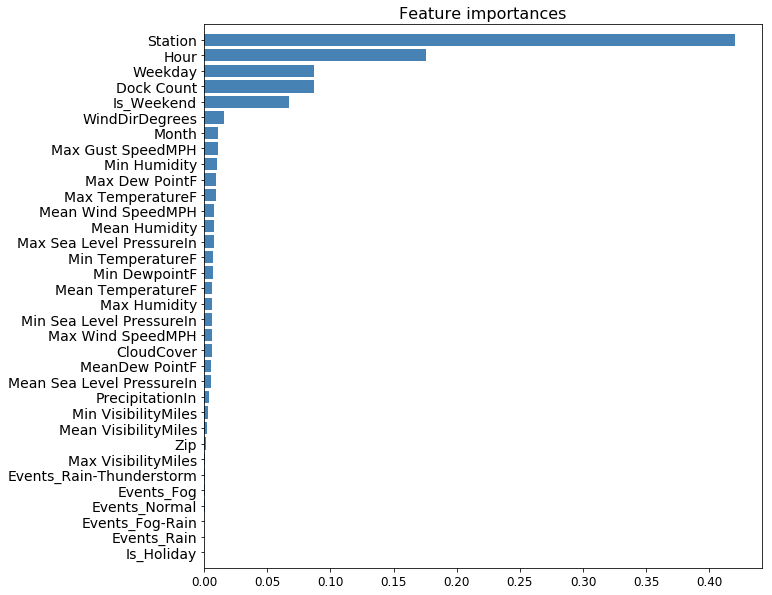

```python
plot_feature_importance(rfr, features, X_train)
```

### Hyperparamter tuning using grid search and cross-validation

**Note:** Normally, we need to set aside a validation set to validate time series data and should not use cross-validation. This is because it ignore the temporal components inherent in the problem. But for this particular problem, I assume the net rate is independent of the day of the month. So I'll use cross-validation to find the hyperparameter here.

```python
importances = rfr.feature_importances_
indices = np.argsort(importances)[::-1]
n_features = 12
new_features = [features[index] for index in indices[:n_features]]
new_features
```

```
['Station',
 'Hour',
 'Weekday',
 'Dock Count',
 'Is_Weekend',
 'WindDirDegrees',
 'Month',
 'Max Gust SpeedMPH',
 'Min Humidity',
 'Max Dew PointF',
 'Max TemperatureF',
 'Mean Wind SpeedMPH']
```

```python
# only use top 12 features
X_train = train[new_features]
X_test = test[new_features]
y_train = train['Net_Rate']
y_test = test['Net_Rate']
```

```python
from sklearn.grid_search import GridSearchCV
from sklearn.metrics import make_scorer

score = make_scorer(calc_rmse, greater_is_better=False)

rfr = RandomForestRegressor(n_jobs=-1, max_features='sqrt')

# Use a grid over parameters of interest
param_grid = {
           "n_estimators" : [50, 100, 200],
           "max_depth" : [5, 10, 20],
           "min_samples_leaf" : [1, 3, 5]}

CV_rfr = GridSearchCV(estimator=rfr, param_grid=param_grid, scoring=score, cv= 5)
CV_rfr.fit(X_train, y_train)
```

```
GridSearchCV(cv=5, error_score='raise',
       estimator=RandomForestRegressor(bootstrap=True, criterion='mse', max_depth=None,
           max_features='sqrt', max_leaf_nodes=None,
           min_impurity_decrease=0.0, min_impurity_split=None,
           min_samples_leaf=1, min_samples_split=2,
           min_weight_fraction_leaf=0.0, n_estimators=10, n_jobs=-1,
           oob_score=False, random_state=None, verbose=0, warm_start=False),
       fit_params={}, iid=True, n_jobs=1,
       param_grid={'n_estimators': [50, 100, 200], 'max_depth': [5, 10, 20], 'min_samples_leaf': [1, 3, 5]},
       pre_dispatch='2*n_jobs', refit=True,
       scoring=make_scorer(calc_rmse, greater_is_better=False), verbose=0)
```

```python
rfr_best = CV_rfr.best_estimator_
rfr_best
```

```
RandomForestRegressor(bootstrap=True, criterion='mse', max_depth=10,
           max_features='sqrt', max_leaf_nodes=None,
           min_impurity_decrease=0.0, min_impurity_split=None,
           min_samples_leaf=1, min_samples_split=2,
           min_weight_fraction_leaf=0.0, n_estimators=200, n_jobs=-1,
           oob_score=False, random_state=None, verbose=0, warm_start=False)
```

```python
print("Random Forest Model, Optimized")
model_evaluation(rfr_best)
```

```
Random Forest Model, Optimized
rmse_train:  0.5426538533652102
rmse_test:  0.5485863153512607
```

```
Feature ranking:
1. feature Station (0.421720)
2. feature Hour (0.180616)
3. feature Weekday (0.094634)
4. feature Dock Count (0.090474)
5. feature Is_Weekend (0.068125)
6. feature WindDirDegrees (0.028930)
7. feature Min Humidity (0.022140)
8. feature Max Dew PointF (0.021235)
9. feature Max TemperatureF (0.020271)
10. feature Max Gust SpeedMPH (0.019577)
11. feature Month (0.017039)
12. feature Mean Wind SpeedMPH (0.015238)
```

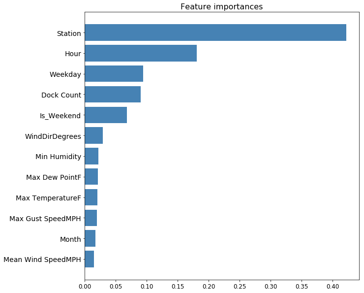

```python
plot_feature_importance(rfr_best, new_features, X_train)
```

# 3. Conclusions and Further Steps

**Here is a brief overview of conclusion and possible future steps. Please see pdf reports for more detail.**

## 3.1 Conclusions

**Important Features**

```
- Station
- Hour
- Dock Count
- Time Related Features: Weekday, Is_Weekend, Month
- Weather Related Features: WindDirDegrees, Gust Speed, Humidity, Dew Point, Temperature, Wind Speed
```

**Results**

```
- Baseline model: test set RMSE: 0.5566
- Random Forest Model: test set RMSE: 0.5485
```

Random Forest Model perform slighly better than the baseline model.

## 3.2 Future Steps

**Feature Engineering:**

```
- Consider geo data, nearby station's traffic/net rate may also have influences
- Incorporate population and/or demographic data of users.
```

**Model Building:**

```
- Further optimize the Random Forest Model or try other tree based models such as Gradient Boosting Regression
- Use PCA to reduce dimentionality and then try other ML algorithms
- Build model for each group/cluster, such as build model for different zipcode
- Time series model, such as ARIMA
```